# An Introductory Example

## Introductory

- We're now ready to start learning the Python language itself, and the next few lectures are devoted to this task
- Our approach is aimed at those who already have at least some knowledge of fundamental programming concepts, such as
  - variables
  - for loops, while loops
  - conditionals (if/else)

## Introductory

- If you have no programming experience, you just need to cover some of the fundamentals of programming before returning here.
- Two good references for first time programmers are
  - Learn Python the Hard Way
  - How to Think Like a Computer Scientist - the first 5 or 6 chapters
  - If you really want to follow some Chinese courses, I recommand python tutorial by [Xuefeng Liao](http://www.liaoxuefeng.com/wiki/0014316089557264a6b348958f449949df42a6d3a2e542c000)

## Overview

## Overview

- In this lecture we will write and then pick apart small Python programs
- The objective is to introduce you to basic Python syntax and data structures
- Deeper concepts-how things work-will be covered in later lectures
- In particular, the scientific libraries will allow us to accomplish the same things much faster and more efficiently, once we know how to use them
- However, you also need to learn pure Python, the core language
- Prerequisites: An understanding of how to run simple programs

## First Example: Plotting a White Noise Process

## First Example: Plotting a White Noise Process

- To begin, let's suppose that we want to simulate and plot the white noise process \(\epsilon_0,\epsilon_1,...,\epsilon_T\), where each draw \(\epsilon_t\) is independent standard normal.
- In other words, we want to generate figures that look something like this:

## First Example: Plotting a White Noise Process

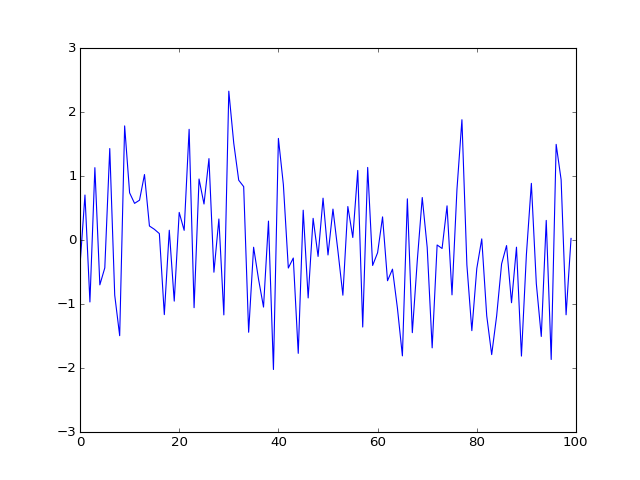

## First Example: Plotting a White Noise Process

```python
from random import normalvariate
import matplotlib.pyplot as plt
ts_length = 100
epsilon_values = []   # An empty list
for i in range(ts_length):
    e = normalvariate(0, 1)
    epsilon_values.append(e)
plt.plot(epsilon_values, 'b-')
plt.show()
```

## First Example: Plotting a White Noise Process

- In brief,
  - Lines 1a2 use the Python `import` keyword to pull in functionality from external libraries
  - Line 3 sets the desired length of the time series
  - Line 4 creates an empty list called `epsilon_values` that will store the \(\epsilon_t\) values as we generate them
  - Line 5 tells the Python interpreter that it should cycle through the block of indented lines (lines 6a7) `ts_length` times before continuing to line 8
    - Lines 6a7 draw a new value \(\epsilon_t\) and append it to the end of the list `epsilon_values`
  - Lines 8a9 generate the plot and display it to the user

## Import Statements

- Consider the line `from random import normalvariate`
- Here `random` is a *module*, which is just a file containing Python code
- The statement `from random import normalvariate` causes the Python interpreter to
  - run the code in a file called `random.py` that was placed in your filesystem when you installed Python
  - make the function `normalvariate` defined in that file available for use in your program

## Import Statements

- If you want to import more attributes you can use a comma separated list, like so:

```python
from random import normalvariate, uniform
normalvariate(0, 1)

uniform(-1, 1)
```

## Import Statements

- Alternatively, you can use the following syntax:

```python
import random
random.normalvariate(0, 1)

random.uniform(-1, 1))
```

## Packages

- Now consider the line `import matplotlib.pyplot as plt`
- Here `matplotlib` is a Python package, and `pyplot` is a subpackage of `matplotlib`
- Packages are used when a developer wants to organize a number of Python files (modules) containing related code
- A package is just a directory containing files containing Python code

## Packages

- By definition, a package always contains a file called `__init__.py` that specifies what code will be run when we type `import package_name`
- Subpackages are the same, except that they are subdirectories of a package directory
- So `import matplotlib.pyplot as plt` runs the `__init__.py` file in the directory `matplotlib/pyplot` and makes the attributes specified in that file available to us
- The keyword `as` in `import matplotlib.pyplot as plt` just lets us access these attributes via as simpler name

## Lists

- Next let's consider the statement `epsilon_values = []`, which creates an empty list
- Lists are a native Python data structure used to group a collection of objects.

```python
x = [10, 'foo', False]  # We can include heterogeneous data inside a list
type(x)
```

## Lists

- Here the first element of x is an integer, the next is a string and the third is a Boolean value
- When adding a value to a list, we can use the syntax `list_name.append(some_value)`

```python
x

x.append(2.5)
x
```

## Lists

- Here `append()` is what's called a *method*, which is a function aattached toa an object-in this case, the list x
- We'll learn all about methods later on, but just to give you some idea,
  - Python objects such as lists, strings, etc. all have methods that are used to manipulate the data contained in the object
  - String objects have string methods, list objects have list methods, etc.

## Lists

- Another useful list method is `pop()`

```python
x.pop()

x
```

## Lists

- Following C, C++, Java, etc., lists in Python are zero based

```python
x[0]

x[1]
```

## Lists

- Returning to the program above, we actually create a second list besides `epsilon_values`
- In particular, line 5 calls the `range()` function, which creates sequential lists of integers

```python
range(4)

range(5)
```

## The For Loop

- Now let's consider the `for` loop in `test_program_1.py`, which we repeat here for convenience, along with the line that follows it

```python
for i in range(ts_length):
    e = normalvariate(0, 1)
    epsilon_values.append(e)
plt.plot(epsilon_values, 'b-')
```

## The For Loop

- The `for` loop causes Python to execute the two indented lines a total of `ts_length` times before moving on
- These two lines are called a `code block`, since they comprise the ablocka of code that we are looping over
- Unlike most other languages, Python knows the extent of the code block *only from indentation*
- In particular, the fact that indentation decreases after line `epsilon_values.append(e)` tells Python that this line marks the lower limit of the code block

## The For Loop

```python
animals = ['dog', 'cat', 'bird']
for animal in animals:
    print("The plural of " + animal + " is " + animal + "s")
```

## The For Loop

- This example helps to clarify how the `for` loop works: When we execute a loop of the form

```python
for variable_name in sequence:`
    <code block>
```

- The Python interpreter performs the following:
  - For each element of `sequence`, it abindsa the name `variable_name` to that element and then executes the code block
- The `sequence` object can in fact be a very general object, as we'll see soon enough

## Code Blocks and Indentation

- In discussing the `for` loop, we explained that the code blocks being looped over are delimited by indentation
- In fact, in Python all code blocks (i.e., those occuring inside loops, if clauses, function definitions, etc.) are delimited by indentation
- Thus, unlike most other languages, whitespace in Python code affects the output of the program
- Once you get used to it, this is a very good thing because it
  - forces clean, consistent indentation, which improves readability
  - removes clutter, such as the brackets or end statements used in other languages

## Code Blocks and Indentation

- On the other hand, it takes a bit of care to get right, so please remember:
  - The line before the start of a code block always ends in a colon
    - for i in range(10):
    - if x > y:
    - while x < 100:
    - etc., etc.
  - All lines in a code block must have the same amount of indentation
  - The Python standard is 4 spaces, and that's what you should use

## Tabs vs Spaces

- One small agotchaa here is the mixing of tabs and spaces (Important: Within text files, the internal representation of tabs and spaces is not the same)
- You can use your Tab key to insert 4 spaces, but you need to make sure it's configured to do so
- If you are using the IPython notebook you will have no problems here (Also, good quality text editors will allow you to configure the Tab key to insert spaces instead of tabs - trying searching on line)

## While Loops

- The `for` loop is the most common technique for iteration in Python
- But, for the purpose of illustration, let's modify `test_program_1.py` to use a `while` loop instead
- In Python, the `while` loop syntax is as shown in the file `test_program_2.py` below

```python
from random import normalvariate
import matplotlib.pyplot as plt
ts_length = 100
epsilon_values = []
i = 0
while i < ts_length:
    e = normalvariate(0, 1)
    epsilon_values.append(e)
    i = i + 1
plt.plot(epsilon_values, 'b-')
plt.show()
```

## While Loops

- The output of `test_program_2.py` is identical to `test_program_1.py` above
- Comments:
  - The code block for the while loop is lines 7a9, again delimited only by indentation
  - The statement `i = i + 1` can be replaced by `i += 1`

## User-Defined Functions

- Now let's go back to the `for` loop, but restructure our program to make the logic clearer
- To this end, we will break our program into two parts:
  - A user-defined function that generates a list of random variables
  - The main part of the program that
    - calls this function to get data
    - plots the data
- This is accomplished in `test_program_3.py`

## User-Defined Functions

```python
from random import normalvariate
import matplotlib.pyplot as plt
def generate_data(n):
    epsilon_values = []
    for i in range(n):
        e = normalvariate(0, 1)
        epsilon_values.append(e)
    return epsilon_values
data = generate_data(100)
plt.plot(data, 'b-')
plt.show()
```

## User-Defined Functions

- Let's go over this carefully, in case you're not familiar with functions and how they work
- We have defined a function called `generate_data()`, where the definition spans lines 3a8
  - `def` on line 3 is a Python keyword used to start function definitions
  - `def generate_data(n)`: indicates that the function is called `generate_data`, and that it has a single argument `n`
  - Lines 4a8 are a code block called the *function body*-in this case it creates an iid list of random draws using the same logic as before
  - Line 8 indicates that the list `epsilon_values` is the object that should be returned to the calling code

## Conditions

- Our function `generate_data()` is rather limited
- Let's make it slightly more useful by giving it the ability to return either standard normals or uniform random variables on (0,1) as required
- This is achieved in `test_program_4.py` by adding the argument `generator_type` to `generate_data()`

## Conditions

```python
from random import normalvariate, uniform
import matplotlib.pyplot as plt
def generate_data(n, generator_type):
    epsilon_values = []
    for i in range(n):
        if generator_type == 'U':
            e = uniform(0, 1)
        else:
            e = normalvariate(0, 1)
        epsilon_values.append(e)
    return epsilon_values
data = generate_data(100, 'U')
plt.plot(data, 'b-')
plt.show()
```

## Conditions

- Comments:
  - Hopefully the syntax of the if/else clause is self-explanatory, with indentation again delimiting the extent of the code blocks
  - We are passing the argument `U` as a string, which is why we write it as `'U'`
  - Notice that equality is tested with the `==` syntax, not `=`
    - For example, the statement `a = 10` assigns the name `a` to the value 10
    - The expression `a == 10` evaluates to either `True` or `False`, depending on the value of `a`
- Now, there are two ways that we can simplify `test_program_4`

## Conditions

- First, Python accepts the following conditional assignment syntax

```python
x = -10
s = 'negative' if x < 0 else 'nonnegative'
s
```

- which leads us to `test_program_5.py`

## Conditions

```python
from random import normalvariate, uniform
import matplotlib.pyplot as plt
def generate_data(n, generator_type):
    epsilon_values = []
    for i in range(n):
        e = uniform(0, 1) if generator_type == 'U' else normalvariate(0, 1)
        epsilon_values.append(e)
    return epsilon_values
data = generate_data(100, 'U')
plt.plot(data, 'b-')
plt.show()
```

## Conditions

- Second, and more importantly, we can get rid of the conditionals all together by just passing the desired generator type *as a function*
- To understand this, consider `test_program_6.py`

```python
from random import uniform
import matplotlib.pyplot as plt
def generate_data(n, generator_type):
    epsilon_values = []
    for i in range(n):
        e = generator_type(0, 1)
        epsilon_values.append(e)
    return epsilon_values
data = generate_data(100, uniform)
plt.plot(data, 'b-')
plt.show()
```

## Conditions

- The only lines that have changed here are lines 6 and 9
- In line 9, when we call the function `generate_data()`, we pass `uniform` as the second argument
- The object `uniform` is in fact a **function**, defined in the `random` module

```python
from random import uniform
uniform(0, 1)
```

## Conditions

- When the function call `generate_data(100, uniform)` is executed, Python runs the code block on lines 3a8 with `n` equal to 100 and the name `generator_type` abounda to the function `uniform`
- While these lines are executed, the names `generator_type` and `uniform` are asynonymsa, and can be used in identical ways.

```python
max(7, 2, 4)   # max() is a built-in Python function

m = max
m(7, 2, 4)
```

- Here we created another name for the built-in function `max()`, which could then be used in identical ways
- In the context of our program, the ability to bind new names to functions means that there is no problem *passing a function as an argument to another function*-as we do

## List Comprehensions

- Now is probably a good time to tell you that we can simplify the code for generating the list of random draws considerably by using something called a *list comprehension*
- List comprehensions are an elegant Python tool for creating lists

```python
animals = ['dog', 'cat', 'bird']
plurals = [animal + 's' for animal in animals]
plurals

range(8)
doubles = [2 * x for x in range(8)]
doubles
```

## List Comprehensions

- With the list comprehension syntax, we can simplify the lines

```python
epsilon_values = []
for i in range(n):
    e = generator_type(0, 1)
    epsilon_values.append(e)
```

```python
epsilon_values = [generator_type(0, 1) for i in range(n)]
```

## Using the Scientific Libraries

- In practice we would use the scientific libraries, which can generate large arrays of independent random draws much more efficiently

```python
from numpy.random import randn
epsilon_values = randn(5)
epsilon_values
```

## Exercises

## Exercises 1

- Recall that \(n!\) is read as an factoriala and defined as \(n!=n\times (n-1) \times ... \times 2\times 1\)
- There are functions to compute this in various modules, but let's write our own version as an exercise
- In particular, write a function `factorial` such that `factorial(n)` returns \(n!\) for any positive integer n

## Exercises 2

- The binomial random variable \(Y\sim Bin(n,p)\) represents the number of successes in n binary trials, where each trial succeeds with probability p
- Without any import besides `from random import uniform`, write a function `binomial_rv` such that `binomial_rv(n, p)` generates one draw of Y
- Hint: If U is uniform on (0,1) and \(p\in(0,1)\), then the expression `U < p` evaluates to `True` with probability p

## Exercises 3

- Compute an approximation to \(\pi\) using Monte Carlo. Use no imports besides

```python
from random import uniform
from math import sqrt
```

- Your hints are as follows:
  - If U is a bivariate uniform random variable on the unit square \((0,1)^2\), then the probability that U lies in a subset B of \((0,1)^2\) is equal to the area of B
  - If \(U_1,...,U_n\) are iid copies of U, then, as n gets large, the fraction that fall in B converges to the probability of landing in B
  - For a circle, area = pi * radius^2

## Exercises 4

- Write a program that prints one realization of the following random device:
  - Flip an unbiased coin 10 times
  - If 3 consecutive heads occur one or more times within this sequence, pay one dollar
  - If not, pay nothing
- Use no import besides `from random import uniform`

## Exercises 5

- Your next task is to simulate and plot the correlated time series \[ x_{t+1}=\alpha x_t+\varepsilon_{t+1} \:\text{where}\: x_0=0 \:\text{and}\: t=0,...,T \]
- The sequence of shocks \({\varepsilon_t}\) is assumed to be iid and standard normal
- In your solution, restrict your import statements to

```python
import matplotlib.pyplot as plt
from random import normalvariate
```

- Set \(T=200\) and \(\alpha=0.9\)

## Exercises 6

- To do the next exercise, you will need to know how to produce a plot legend

```python
from pylab import plot, show, legend
from random import normalvariate
x = [normalvariate(0, 1) for i in range(100)]
plot(x, 'b-', label="white noise")
legend()
show()
```

## Exercises 6

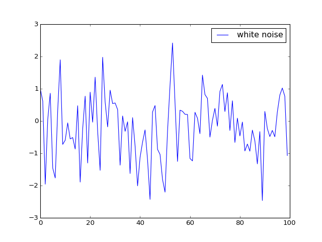

## Exercises 6

- Now, starting with your solution to exercise 5, plot three simulated time series, one for each of the cases \(\alpha=0\), \(\alpha=0.8\) and \(\alpha=0.98\)
- In particular, you should produce a figure that looks as follows

## Exercises 6

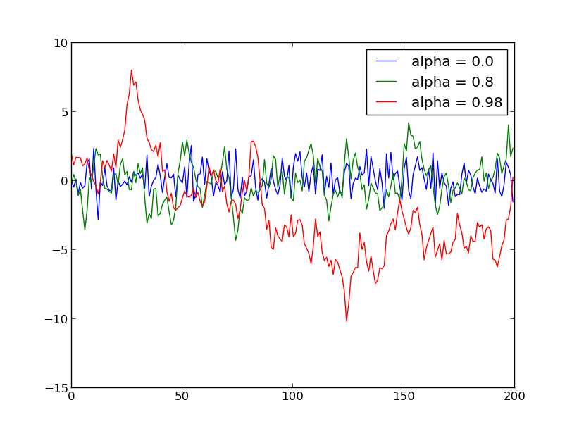

## Exercises 6

- In your solution, please restrict your import statements to

```python
import matplotlib.pyplot as plt
from random import normalvariate
```

- Also, use a `for` loop to step through the \(\alpha\) values
- Important hints:
  - If you call the `plot()` function multiple times before calling `show()`, all of the lines you produce will end up on the same figure
    - And if you omit the argument `'b-'` to the plot function, Matplotlib will automatically select different colors for each line
  - The expression `'foo' + str(42)` evaluates to `'foo42'`